# 자살공화국, 한국

## 최근 30년 간 자살률 추이 탐색

Hyunju

2019년 6월 13일

## 자살공화국

- 2016년 통계 기준 (출처: [2018 자살예방백서](http://spckorea-stat.or.kr/boadpublishview.do))
1. 자살은 전체 사망원인의 5위
2. 자살 사망자 한 해 13,092명
3. 자살률 25.8명/10만명

[figure not shown]

*마포대교 생명의 다리*

## OECD 국가 자살률

[figure not shown]

## OECD 국가 자살률

- 13년 간 OECD 자살률 1위 기록(2005-2017년)
- 2018년 OECD 자살률 2위로 하락
- 2018년에 한국 자살률이 낮아진 것일까?

## 리투아니아의 OECD 가입

[figure not shown]

## 자살로 인한 비용

- 자살로 인한 사회적 손실:9.4조원(2015년 한 해 기준)
- 특히 노인 자살의 비율이 높게 나타남

[figure not shown]

## 노인 자살의 원인

[figure not shown]

## 국가 목표

2022년까지 자살자 수를 10만 명 당 17.0명으로 감소시키는 것

- *자살률이 가장 높았던 2011년의 절반 수준*

## 관련 법률

[자살예방 및 생명존중문화 조성을 위한 법률](http://www.law.go.kr/LSW/lsInfoP.do?lsiSeq=206690#0000)

제7조: 자살예방기본계획의 수립

1. 국가는 자살예방정책을 효과적으로 추진하기 위하여 자살예방기본계획(이하 "기본계획"이라 한다)을 5년마다 수립하여야 한다.
2. 기본계획에는 다음 각 호의 사항이 포함되어야 한다.
   - 생명존중문화의 조성
   - 자살상담매뉴얼 개발 및 보급
   - 아동ㆍ청소년ㆍ중년층ㆍ노인 등 생애주기별 자살예방대책
   - 정보통신 등 다양한 매체를 이용한 자살예방체계 구축
   - 자살 감시체계의 구축
   - 자살예방 교육 및 훈련
   - 자살예방에 대한 연구지원

## 연구 목적

최근 30년 동안의 전세계 자살률 추이를 탐색하고 한국의 자살률 변화 추이와 비교한다.

## 분담

- 지현주: 데이터 소개
- 강형구: 데이터 시각화
- 윤예슬: 데이터 시각화(API 이용)

## 데이터

[Suicide Rates Overview 1985 to 2016](https://www.kaggle.com/russellyates88/suicide-rates-overview-1985-to-2016)

| 변수 | 변수명 | 변수 | 변수명 |
| --- | --- | --- | --- |
| 국가 | country | **연도** | year |
| 성별 | sex | **연령대** | age |
| 자살자 수 | suicides_no | **인구** | population |
| 자살률 | suicides/100k pop | **Human Development Index** | HDI for year |
| GDP | gdp_for_year | **1인당 GDP** | gdp_per_capita |

## 데이터 소개

```
##           국가            연도          성별               연령대
##  Austria    :  382   Min.   :1985   female:13910   15-24 years:4642
##  Iceland    :  382   1st Qu.:1995   male  :13910   25-34 years:4642
##  Mauritius  :  382   Median :2002                  35-54 years:4642
##  Netherlands:  382   Mean   :2001                  5-14 years :4610
##  Argentina  :  372   3rd Qu.:2008                  55-74 years:4642
##  Belgium    :  372   Max.   :2016                  75+ years  :4642
##  (Other)    :25548
##    자살자 수            인구              자살률             국가-연도
##  Min.   :    0.0   Min.   :     278   Min.   :  0.00   Albania1987:   12
##  1st Qu.:    3.0   1st Qu.:   97498   1st Qu.:  0.92   Albania1988:   12
##  Median :   25.0   Median :  430150   Median :  5.99   Albania1989:   12
##  Mean   :  242.6   Mean   : 1844794   Mean   : 12.82   Albania1992:   12
##  3rd Qu.:  131.0   3rd Qu.: 1486143   3rd Qu.: 16.62   Albania1993:   12
##  Max.   :22338.0   Max.   :43805214   Max.   :224.97   Albania1994:   12
##                                                        (Other)    :27748
##       HDI                       GDP          1인당 GDP
##  Min.   :0.483   1,002,219,052,968:   12   Min.   :   251
##  1st Qu.:0.713   1,011,797,457,139:   12   1st Qu.:  3447
##  Median :0.779   1,016,418,229    :   12   Median :  9372
##  Mean   :0.777   1,018,847,043,277:   12   Mean   : 16866
##  3rd Qu.:0.855   1,022,191,296    :   12   3rd Qu.: 24874
##  Max.   :0.944   1,023,196,003,075:   12   Max.   :126352
##  NA's   :19456   (Other)          :27748
##               세대
##  Boomers        :4990
##  G.I. Generation:2744
##  Generation X   :6408
##  Generation Z   :1470
##  Millenials     :5844
##  Silent         :6364
##
```

## 한국 data

```
##                nation year    sex         age suicides_no population
## 1   Republic of Korea 1985   male   75+ years          42     154800
## 2   Republic of Korea 1985   male 55-74 years         393    1498300
## 3   Republic of Korea 1985   male 35-54 years         903    4285700
## 4   Republic of Korea 1985   male 25-34 years         655    3616800
## 5   Republic of Korea 1985   male 15-24 years         678    4413000
## 6   Republic of Korea 1985 female   75+ years          38     370700
## 7   Republic of Korea 1985 female 55-74 years         161    2000500
## 8   Republic of Korea 1985 female 15-24 years         296    4148300
## 9   Republic of Korea 1985 female 25-34 years         228    3568800
## 10  Republic of Korea 1985 female 35-54 years         262    4267400
## 11  Republic of Korea 1985   male  5-14 years          20    4336000
## 12  Republic of Korea 1985 female  5-14 years          13    4056400
## 13  Republic of Korea 1986   male   75+ years          59     160500
## 14  Republic of Korea 1986   male 55-74 years         377    1555500
```

[output cut: 1104 more lines]

## 한국 남성의 자살률 변화

[figure not shown]

## 한국 남성의 자살률 변화

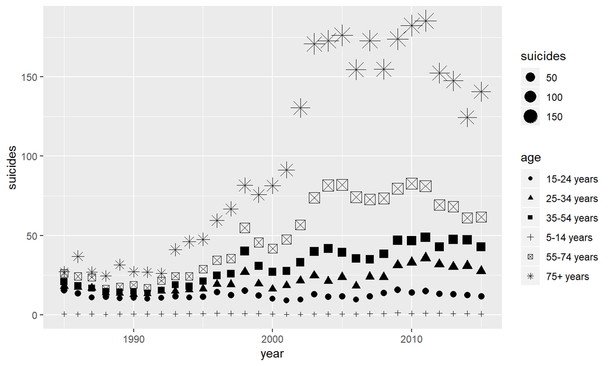

## 한국 여성의 자살률 변화

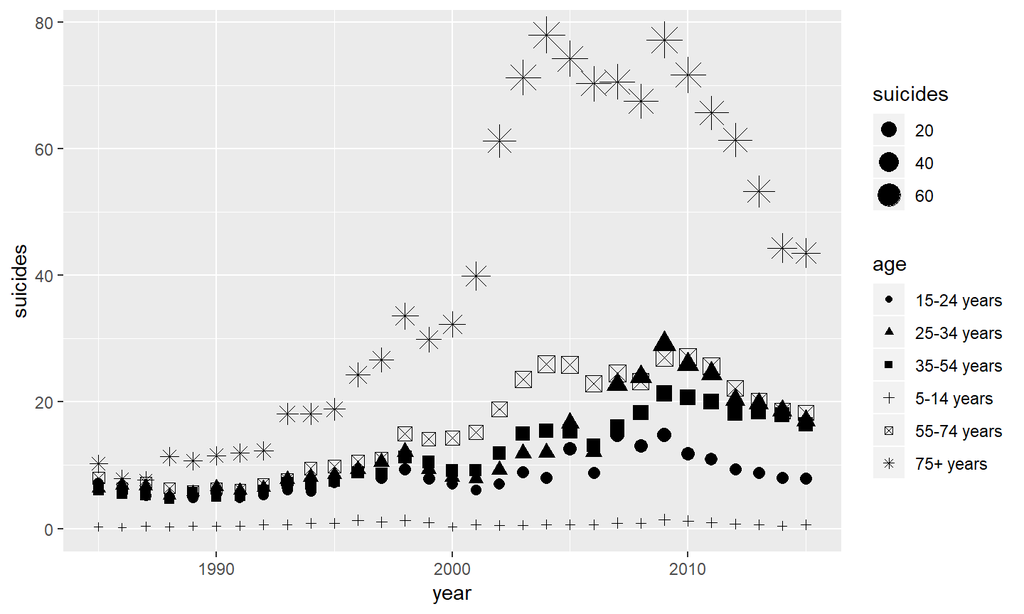